# Machine Learning

## What is Machine Learning?

Machine learning is a subject typically considered part of computer science. It involves the development of flexible algorithms that can *learn patterns from data*. These learned patterns can then help understand inherent patterns in the data (*unsupervised learning*) or make predictions on a target using the learned patterns/relationships (*supervised learning*).

What do we mean when we say "learn patterns from data"? Let's start with a picture.

```
import numpy as np
import sklearn
import matplotlib.pyplot as plt
from sklearn.datasets import make_blobs

x1, y1 = make_blobs(n_features = 2, centers = 3, random_state=24)
plt.scatter(x1[:,0], x1[:,1], marker='o', c=y1, s=20, edgecolor='k')
plt.show()
```

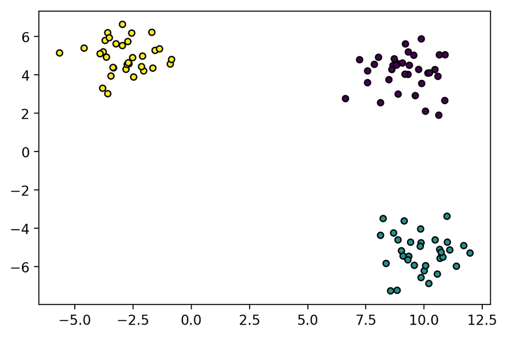

Visually, it is clear that there are 3 groups of observations here, each with a different color. The computer has to learn to figure this out. Since there is clear separation of the groups, this is perhaps not so hard, but might teach us how to make the computer learn.

First, let's see if we can have the computer learn a vertical line that would let everything to its left will be yellow. This is visually an easy task. Let's see how we can make the computer learn this using Python. First, the colors are coded numerically in Python as follows:

- black = 0
- blue = 1
- yellow = 2

The following code instructs the computer to construct 100 points along the x-axis, then ask for the first time when all the points to the left of one of these points is yellow, and no point on the other side is yellow. We then draw that line.

```
test_x = np.linspace(np.min(x1[:,0]), np.max(x1[:,0]), 100)
candidate_x = -5
for x in test_x[1:-1]:
  yellow_to_right = (y1[x1[:,0] > x] == 2)
  if np.sum(yellow_to_right)==0:
    candidate_x = x
    break

plt.scatter(x1[:,0], x1[:,1], marker='o', c=y1, s=20, edgecolor='k')
plt.axvline(x=candidate_x)
plt.show()
```

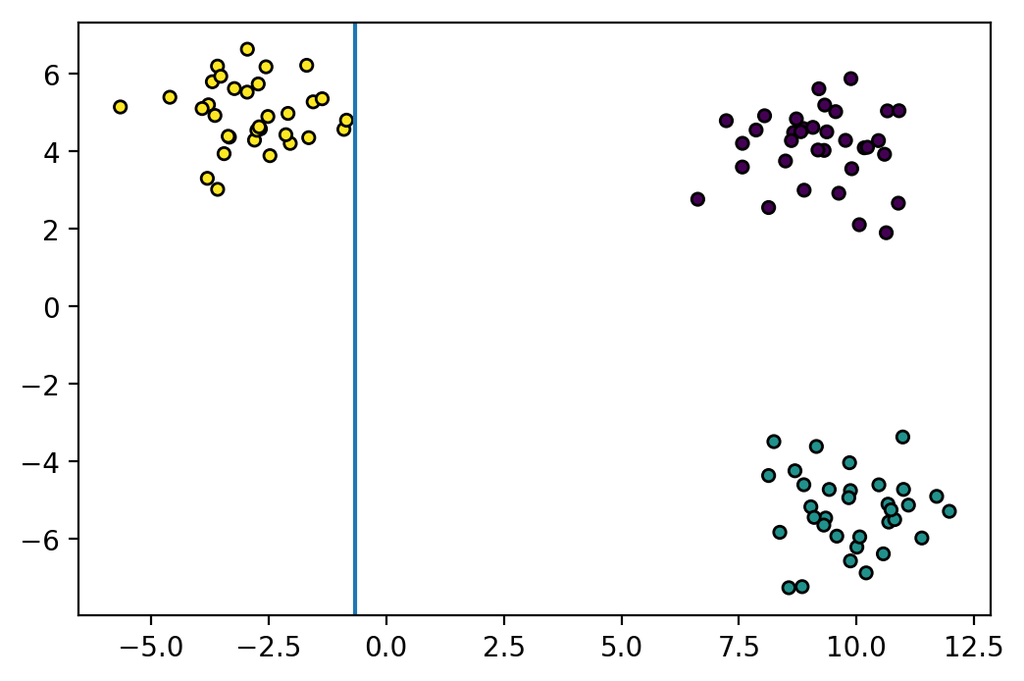

Look, the computer learned something. It learned that points with the x-value < -0.66 are yellow.

Now, lets see if we can have the computer learn to discover where the blue points are among the non-yellow points. We'll use very similar code as above.

```
test_y = np.linspace(np.min(x1[:,1]), np.max(x1[:,1]), 100)
# restrict to data to the right of -0.66
x2 = x1[x1[:,0] > candidate_x, :]
y2 = y1[x1[:,0] > candidate_x]
candidate_y = -10
for y in test_y[1:-1]:
  blue_below = (y2[x2[:,1] > y] == 1)
  if np.sum(blue_below)==0:
    candidate_y = y
    break

plt.scatter(x1[:,0], x1[:,1], marker='o', c=y1, s=20, edgecolor='k')
plt.axvline(x = candidate_x)
plt.plot([candidate_x, np.max(x1[:,0])], [candidate_y+0.1, candidate_y+0.1])
plt.show()
```

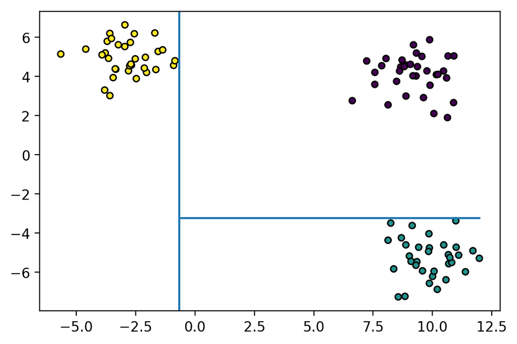

This time, the computer learned, among the non-yellow points, if y-values are less than -3.33, they are blue. Knowing we have only three colors, we know the rest are black.

So the computer learned the following from this process:

Rule Outcome

x-value < -0.66 yellow x-value > -0.66, y-value < -3.33 blue x-value > -0.66, y-value > -3.33 black

This is called **training the algorithm**, in that the computer is trained from the data it saw to call the color of the data based on x and y values. Now, if the computer is given new (x,y) data, it will predict its color following the table above. This is the *prediction rule* that the algorithm will use on new data.

### Summary

Published from 03-Machine-Learning.pmd using [Pweave](http://mpastell.com/pweave) 0.30.1 on 15-10-2017.